# Credit Card Users Churn Prediction

## Problem Statement

### Business Context

The Thera bank recently saw a steep decline in the number of users of their credit card, credit cards are a good source of income for banks because of different kinds of fees charged by the banks like annual fees, balance transfer fees, and cash advance fees, late payment fees, foreign transaction fees, and others. Some fees are charged to every user irrespective of usage, while others are charged under specified circumstances.

Customers’ leaving credit cards services would lead bank to loss, so the bank wants to analyze the data of customers and identify the customers who will leave their credit card services and reason for same – so that bank could improve upon those areas

You as a Data scientist at Thera bank need to come up with a classification model that will help the bank improve its services so that customers do not renounce their credit cards

### Data Description

- CLIENTNUM: Client number. Unique identifier for the customer holding the account
- Attrition_Flag: Internal event (customer activity) variable - if the account is closed then "Attrited Customer" else "Existing Customer"
- Customer_Age: Age in Years
- Gender: Gender of the account holder
- Dependent_count: Number of dependents
- Education_Level: Educational Qualification of the account holder - Graduate, High School, Unknown, Uneducated, College(refers to college student), Post-Graduate, Doctorate
- Marital_Status: Marital Status of the account holder
- Income_Category: Annual Income Category of the account holder
- Card_Category: Type of Card
- Months_on_book: Period of relationship with the bank (in months)
- Total_Relationship_Count: Total no. of products held by the customer
- Months_Inactive_12_mon: No. of months inactive in the last 12 months
- Contacts_Count_12_mon: No. of Contacts in the last 12 months
- Credit_Limit: Credit Limit on the Credit Card
- Total_Revolving_Bal: Total Revolving Balance on the Credit Card
- Avg_Open_To_Buy: Open to Buy Credit Line (Average of last 12 months)
- Total_Amt_Chng_Q4_Q1: Change in Transaction Amount (Q4 over Q1)
- Total_Trans_Amt: Total Transaction Amount (Last 12 months)
- Total_Trans_Ct: Total Transaction Count (Last 12 months)
- Total_Ct_Chng_Q4_Q1: Change in Transaction Count (Q4 over Q1)
- Avg_Utilization_Ratio: Average Card Utilization Ratio

#### What Is a Revolving Balance?

- If we don't pay the balance of the revolving credit account in full every month, the unpaid portion carries over to the next month. That's called a revolving balance

##### What is the Average Open to buy?

- 'Open to Buy' means the amount left on your credit card to use. Now, this column represents the average of this value for the last 12 months.

##### What is the Average utilization Ratio?

- The Avg_Utilization_Ratio represents how much of the available credit the customer spent. This is useful for calculating credit scores.

##### Relation b/w Avg_Open_To_Buy, Credit_Limit and Avg_Utilization_Ratio:

- ( Avg_Open_To_Buy / Credit_Limit ) + Avg_Utilization_Ratio = 1

### **Please read the instructions carefully before starting the project.**

This is a commented Jupyter IPython Notebook file in which all the instructions and tasks to be performed are mentioned.

- Blanks '_______' are provided in the notebook that needs to be filled with an appropriate code to get the correct result. With every '_______' blank, there is a comment that briefly describes what needs to be filled in the blank space.
- Identify the task to be performed correctly, and only then proceed to write the required code.
- Fill the code wherever asked by the commented lines like "# write your code here" or "# complete the code". Running incomplete code may throw error.
- Please run the codes in a sequential manner from the beginning to avoid any unnecessary errors.
- Add the results/observations (wherever mentioned) derived from the analysis in the presentation and submit the same.

## Importing necessary libraries

```python
# import libraries for data manipulation
import numpy as np
import pandas as pd

# import libraries for data visualization
import matplotlib.pyplot as plt
import seaborn as sns

# import libraries for model
from sklearn.linear_model import LinearRegression
from sklearn.tree import DecisionTreeClassifier
from sklearn.model_selection import train_test_split
from sklearn.metrics import recall_score, confusion_matrix
from sklearn.metrics import accuracy_score, precision_score
from sklearn.metrics import confusion_matrix
from sklearn.metrics import roc_curve
from sklearn.metrics import make_scorer
from sklearn.metrics import classification_report
from sklearn.tree import plot_tree
from sklearn.model_selection import GridSearchCV
from sklearn.model_selection import RandomizedSearchCV
from imblearn.over_sampling import SMOTE
from imblearn.under_sampling import RandomUnderSampler
from sklearn.preprocessing import LabelEncoder
from sklearn.ensemble import BaggingClassifier
from sklearn.ensemble import RandomForestClassifier
from sklearn.ensemble import AdaBoostClassifier
from sklearn.ensemble import GradientBoostingClassifier
from xgboost import XGBClassifier
```

## Loading the dataset

```python
# read the data
df = pd.read_csv('BankChurners.csv')
# returns the first 5 rows
df.head()
```

|  | CLIENTNUM | Attrition_Flag | Customer_Age | Gender | Dependent_count | Education_Level | Marital_Status | Income_Category | Card_Category | Months_on_book | ... | Months_Inactive_12_mon | Contacts_Count_12_mon | Credit_Limit | Total_Revolving_Bal | Avg_Open_To_Buy | Total_Amt_Chng_Q4_Q1 | Total_Trans_Amt | Total_Trans_Ct | Total_Ct_Chng_Q4_Q1 | Avg_Utilization_Ratio |
| --- | --- | --- | --- | --- | --- | --- | --- | --- | --- | --- | --- | --- | --- | --- | --- | --- | --- | --- | --- | --- | --- |
| 0 | 768805383 | Existing Customer | 45 | M | 3 | High School | Married | $60K - $80K | Blue | 39 | ... | 1 | 3 | 12691.0 | 777 | 11914.0 | 1.335 | 1144 | 42 | 1.625 | 0.061 |
| 1 | 818770008 | Existing Customer | 49 | F | 5 | Graduate | Single | Less than $40K | Blue | 44 | ... | 1 | 2 | 8256.0 | 864 | 7392.0 | 1.541 | 1291 | 33 | 3.714 | 0.105 |
| 2 | 713982108 | Existing Customer | 51 | M | 3 | Graduate | Married | $80K - $120K | Blue | 36 | ... | 1 | 0 | 3418.0 | 0 | 3418.0 | 2.594 | 1887 | 20 | 2.333 | 0.000 |
| 3 | 769911858 | Existing Customer | 40 | F | 4 | High School | NaN | Less than $40K | Blue | 34 | ... | 4 | 1 | 3313.0 | 2517 | 796.0 | 1.405 | 1171 | 20 | 2.333 | 0.760 |
| 4 | 709106358 | Existing Customer | 40 | M | 3 | Uneducated | Married | $60K - $80K | Blue | 21 | ... | 1 | 0 | 4716.0 | 0 | 4716.0 | 2.175 | 816 | 28 | 2.500 | 0.000 |

5 rows × 21 columns

## Data Overview

- Observations
- Sanity checks

### Rows and columns

```python
print("Number of rows:", df.shape[0])
print("Number of columns:", df.shape[1])
```

```
Number of rows: 10127
Number of columns: 21
```

### Data types

```python
df.info()
```

```
<class 'pandas.core.frame.DataFrame'>
RangeIndex: 10127 entries, 0 to 10126
Data columns (total 21 columns):
 #   Column                    Non-Null Count  Dtype
---  ------                    --------------  -----
 0   CLIENTNUM                 10127 non-null  int64
 1   Attrition_Flag            10127 non-null  object
 2   Customer_Age              10127 non-null  int64
 3   Gender                    10127 non-null  object
 4   Dependent_count           10127 non-null  int64
 5   Education_Level           8608 non-null   object
 6   Marital_Status            9378 non-null   object
 7   Income_Category           10127 non-null  object
 8   Card_Category             10127 non-null  object
 9   Months_on_book            10127 non-null  int64
 10  Total_Relationship_Count  10127 non-null  int64
 11  Months_Inactive_12_mon    10127 non-null  int64
 12  Contacts_Count_12_mon     10127 non-null  int64
 13  Credit_Limit              10127 non-null  float64
 14  Total_Revolving_Bal       10127 non-null  int64
 15  Avg_Open_To_Buy           10127 non-null  float64
 16  Total_Amt_Chng_Q4_Q1      10127 non-null  float64
 17  Total_Trans_Amt           10127 non-null  int64
 18  Total_Trans_Ct            10127 non-null  int64
 19  Total_Ct_Chng_Q4_Q1       10127 non-null  float64
 20  Avg_Utilization_Ratio     10127 non-null  float64
dtypes: float64(5), int64(10), object(6)
memory usage: 1.6+ MB
```

### Missing values

```python
print(df.isnull().sum())
```

```
CLIENTNUM                      0
Attrition_Flag                 0
Customer_Age                   0
Gender                         0
Dependent_count                0
Education_Level             1519
Marital_Status               749
Income_Category                0
Card_Category                  0
Months_on_book                 0
Total_Relationship_Count       0
Months_Inactive_12_mon         0
Contacts_Count_12_mon          0
Credit_Limit                   0
Total_Revolving_Bal            0
Avg_Open_To_Buy                0
Total_Amt_Chng_Q4_Q1           0
Total_Trans_Amt                0
Total_Trans_Ct                 0
Total_Ct_Chng_Q4_Q1            0
Avg_Utilization_Ratio          0
dtype: int64
```

- Lots of missing values for Education level and Marital Status. We will come back to that later.

### Duplicate rows

```python
print(df.duplicated().sum())
```

```
0
```

- No duplicate rows, so thankfully we don't have to worry about that right now.

### Negative values

```python
numeric_cols = df.select_dtypes(include=[float, int])
result = numeric_cols.lt(0).sum()
print(result)
```

```
CLIENTNUM                   0
Customer_Age                0
Dependent_count             0
Months_on_book              0
Total_Relationship_Count    0
Months_Inactive_12_mon      0
Contacts_Count_12_mon       0
Credit_Limit                0
Total_Revolving_Bal         0
Avg_Open_To_Buy             0
Total_Amt_Chng_Q4_Q1        0
Total_Trans_Amt             0
Total_Trans_Ct              0
Total_Ct_Chng_Q4_Q1         0
Avg_Utilization_Ratio       0
dtype: int64
```

No negative values, so we don't have to worry about that either.

### Unique values

```python
for col in df.columns:
    print(f"{col}: {df[col].unique()}")
```

[output not shown]

[output cut: 125 more lines]

[output not shown]

- This helps us identify all the unique values in each categorical variable.
- What is abc in income? We will have to look more closely at that later.

### Data summary

```python
df.describe()
```

|  | CLIENTNUM | Customer_Age | Dependent_count | Months_on_book | Total_Relationship_Count | Months_Inactive_12_mon | Contacts_Count_12_mon | Credit_Limit | Total_Revolving_Bal | Avg_Open_To_Buy | Total_Amt_Chng_Q4_Q1 | Total_Trans_Amt | Total_Trans_Ct | Total_Ct_Chng_Q4_Q1 | Avg_Utilization_Ratio |
| --- | --- | --- | --- | --- | --- | --- | --- | --- | --- | --- | --- | --- | --- | --- | --- |
| count | 1.012700e+04 | 10127.000000 | 10127.000000 | 10127.000000 | 10127.000000 | 10127.000000 | 10127.000000 | 10127.000000 | 10127.000000 | 10127.000000 | 10127.000000 | 10127.000000 | 10127.000000 | 10127.000000 | 10127.000000 |
| mean | 7.391776e+08 | 46.325960 | 2.346203 | 35.928409 | 3.812580 | 2.341167 | 2.455317 | 8631.953698 | 1162.814061 | 7469.139637 | 0.759941 | 4404.086304 | 64.858695 | 0.712222 | 0.274894 |
| std | 3.690378e+07 | 8.016814 | 1.298908 | 7.986416 | 1.554408 | 1.010622 | 1.106225 | 9088.776650 | 814.987335 | 9090.685324 | 0.219207 | 3397.129254 | 23.472570 | 0.238086 | 0.275691 |
| min | 7.080821e+08 | 26.000000 | 0.000000 | 13.000000 | 1.000000 | 0.000000 | 0.000000 | 1438.300000 | 0.000000 | 3.000000 | 0.000000 | 510.000000 | 10.000000 | 0.000000 | 0.000000 |
| 25% | 7.130368e+08 | 41.000000 | 1.000000 | 31.000000 | 3.000000 | 2.000000 | 2.000000 | 2555.000000 | 359.000000 | 1324.500000 | 0.631000 | 2155.500000 | 45.000000 | 0.582000 | 0.023000 |
| 50% | 7.179264e+08 | 46.000000 | 2.000000 | 36.000000 | 4.000000 | 2.000000 | 2.000000 | 4549.000000 | 1276.000000 | 3474.000000 | 0.736000 | 3899.000000 | 67.000000 | 0.702000 | 0.176000 |
| 75% | 7.731435e+08 | 52.000000 | 3.000000 | 40.000000 | 5.000000 | 3.000000 | 3.000000 | 11067.500000 | 1784.000000 | 9859.000000 | 0.859000 | 4741.000000 | 81.000000 | 0.818000 | 0.503000 |
| max | 8.283431e+08 | 73.000000 | 5.000000 | 56.000000 | 6.000000 | 6.000000 | 6.000000 | 34516.000000 | 2517.000000 | 34516.000000 | 3.397000 | 18484.000000 | 139.000000 | 3.714000 | 0.999000 |

Observations:

- In summary, there are 1519 missing values in Education and missing values in marital status, no duplicate rows.
- There are 10127 rows and 21 columns.
- Need to do more research on what abc is in Income brackets.

## Exploratory Data Analysis (EDA)

- EDA is an important part of any project involving data.
- It is important to investigate and understand the data better before building a model with it.
- A few questions have been mentioned below which will help you approach the analysis in the right manner and generate insights from the data.
- A thorough analysis of the data, in addition to the questions mentioned below, should be done.

#### The below functions need to be defined to carry out the Exploratory Data Analysis.

```python
# function to plot a boxplot and a histogram along the same scale.


def histogram_boxplot(data, feature, figsize=(12, 7), kde=False, bins=None):
    """
    Boxplot and histogram combined

    data: dataframe
    feature: dataframe column
    figsize: size of figure (default (12,7))
    kde: whether to the show density curve (default False)
    bins: number of bins for histogram (default None)
    """
    f2, (ax_box2, ax_hist2) = plt.subplots(
        nrows=2,  # Number of rows of the subplot grid= 2
        sharex=True,  # x-axis will be shared among all subplots
        gridspec_kw={"height_ratios": (0.25, 0.75)},
        figsize=figsize,
    )  # creating the 2 subplots
    sns.boxplot(
        data=data, x=feature, ax=ax_box2, showmeans=True, color="violet"
    )  # boxplot will be created and a triangle will indicate the mean value of the column
    sns.histplot(
        data=data, x=feature, kde=kde, ax=ax_hist2, bins=bins, palette="winter"
    ) if bins else sns.histplot(
        data=data, x=feature, kde=kde, ax=ax_hist2
    )  # For histogram
    ax_hist2.axvline(
        data[feature].mean(), color="green", linestyle="--"
    )  # Add mean to the histogram
    ax_hist2.axvline(
        data[feature].median(), color="black", linestyle="-"
    )  # Add median to the histogram
```

```python
# function to create labeled barplots


def labeled_barplot(data, feature, perc=False, n=None):
    """
    Barplot with percentage at the top

    data: dataframe
    feature: dataframe column
    perc: whether to display percentages instead of count (default is False)
    n: displays the top n category levels (default is None, i.e., display all levels)
    """

    total = len(data[feature])  # length of the column
    count = data[feature].nunique()
    if n is None:
        plt.figure(figsize=(count + 1, 5))
    else:
        plt.figure(figsize=(n + 1, 5))

    plt.xticks(rotation=90, fontsize=15)
    ax = sns.countplot(
        data=data,
        x=feature,
        palette="Paired",
        order=data[feature].value_counts().index[:n].sort_values(),
    )

    for p in ax.patches:
        if perc == True:
            label = "{:.1f}%".format(
                100 * p.get_height() / total
            )  # percentage of each class of the category
        else:
            label = p.get_height()  # count of each level of the category

        x = p.get_x() + p.get_width() / 2  # width of the plot
        y = p.get_height()  # height of the plot

        ax.annotate(
            label,
            (x, y),
            ha="center",
            va="center",
            size=12,
            xytext=(0, 5),
            textcoords="offset points",
        )  # annotate the percentage

    plt.show()  # show the plot
```

```python
# function to plot stacked bar chart

def stacked_barplot(data, predictor, target):
    """
    Print the category counts and plot a stacked bar chart

    data: dataframe
    predictor: independent variable
    target: target variable
    """
    count = data[predictor].nunique()
    sorter = data[target].value_counts().index[-1]
    tab1 = pd.crosstab(data[predictor], data[target], margins=True).sort_values(
        by=sorter, ascending=False
    )
    print(tab1)
    print("-" * 120)
    tab = pd.crosstab(data[predictor], data[target], normalize="index").sort_values(
        by=sorter, ascending=False
    )
    tab.plot(kind="bar", stacked=True, figsize=(count + 1, 5))
    plt.legend(
        loc="lower left", frameon=False,
    )
    plt.legend(loc="upper left", bbox_to_anchor=(1, 1))
    plt.show()
```

```python
### Function to plot distributions

def distribution_plot_wrt_target(data, predictor, target):

    fig, axs = plt.subplots(2, 2, figsize=(12, 10))

    target_uniq = data[target].unique()

    axs[0, 0].set_title("Distribution of target for target=" + str(target_uniq[0]))
    sns.histplot(
        data=data[data[target] == target_uniq[0]],
        x=predictor,
        kde=True,
        ax=axs[0, 0],
        color="teal",
    )

    axs[0, 1].set_title("Distribution of target for target=" + str(target_uniq[1]))
    sns.histplot(
        data=data[data[target] == target_uniq[1]],
        x=predictor,
        kde=True,
        ax=axs[0, 1],
        color="orange",
    )

    axs[1, 0].set_title("Boxplot w.r.t target")
    sns.boxplot(data=data, x=target, y=predictor, ax=axs[1, 0], palette="gist_rainbow")

    axs[1, 1].set_title("Boxplot (without outliers) w.r.t target")
    sns.boxplot(
        data=data,
        x=target,
        y=predictor,
        ax=axs[1, 1],
        showfliers=False,
        palette="gist_rainbow",
    )

    plt.tight_layout()
    plt.show()
```

**Questions**:

1. How is the total transaction amount distributed?

```
count    10127.000000
mean      4404.086304
std       3397.129254
min        510.000000
25%       2155.500000
50%       3899.000000
75%       4741.000000
max      18484.000000
Name: Total_Trans_Amt, dtype: float64
```

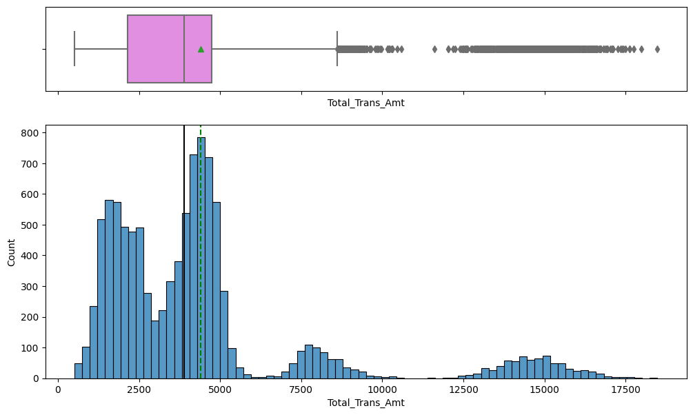

```python
histogram_boxplot(df, 'Total_Trans_Amt')

df['Total_Trans_Amt'].describe()
```

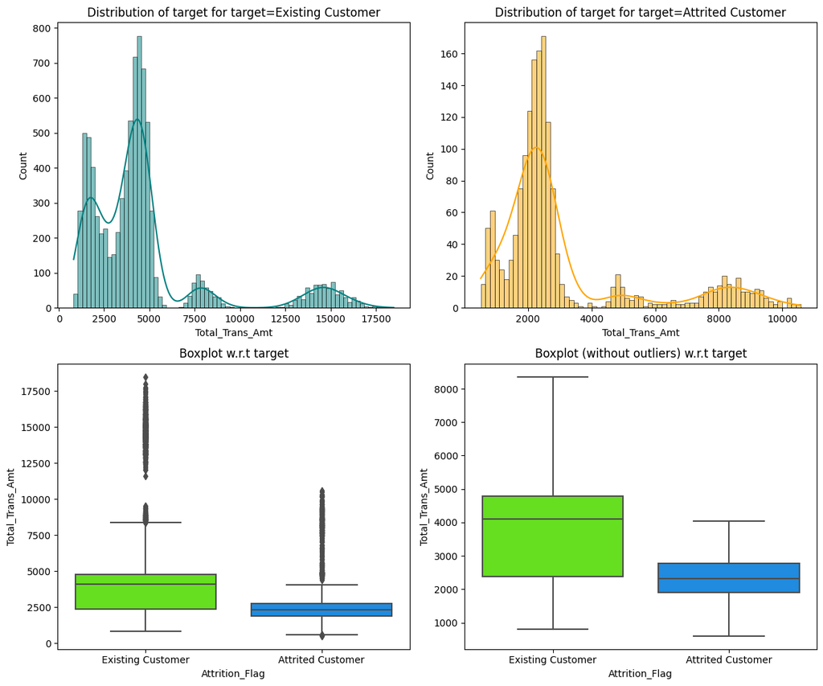

```python
distribution_plot_wrt_target(df, 'Total_Trans_Amt', 'Attrition_Flag')
```

- Seems existing customers have on average roughly 1500 more transactions than attrited customers.
2. What is the distribution of the level of education of customers?

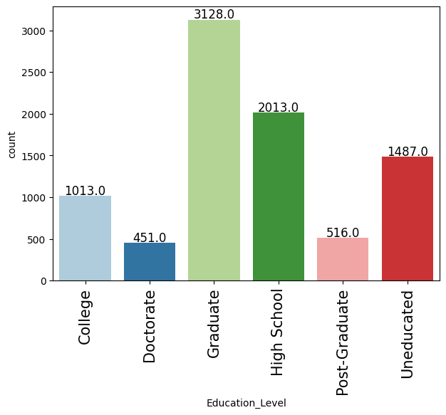

```
count         8608
unique           6
top       Graduate
freq          3128
Name: Education_Level, dtype: object
```

```python
labeled_barplot(df, 'Education_Level')

df['Education_Level'].describe()
```

- The top 3 education levels are Graduate by a significant margin, High School, and Uneducated.
- This distribution of education levels at least at first glance seems more about the distribution of education levels amongst people in general than education levels of those with credit cards.
- Example: Very few people have Doctorates or Masters degrees, so naturally they are the lowest 2 numbers.
- People actively in College probably don't have the disposable income for a credit card.
- People with Bachelor's degrees both have more disposable income than High School and Uneducated people, and they are a more common group of people than people with Doctorates and Masters degrees, so it makes sense they would be the highest sample sized group, being a happy medium of population density and disposable income.

```
Attrition_Flag   Attrited Customer  Existing Customer   All
Education_Level
All                           1371               7237  8608
Graduate                       487               2641  3128
High School                    306               1707  2013
Uneducated                     237               1250  1487
College                        154                859  1013
Doctorate                       95                356   451
Post-Graduate                   92                424   516
------------------------------------------------------------------------------------------------------------------------
```

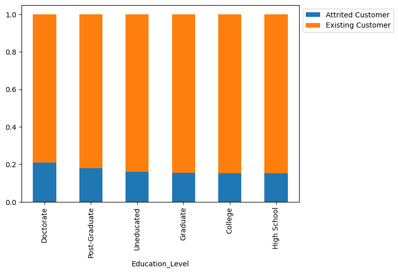

```python
stacked_barplot(df, 'Education_Level', 'Attrition_Flag')
```

- Interestingly, although the ratios of attrition vs. existing amongst all education levels is fairly uniform, it seems people with Doctorate and Post-Graduate degrees are the people most likely to close their accounts. You would not think this to be the case, as these people likely have the most disposable income. Worth further analysis.
3. What is the distribution of the level of income of customers?

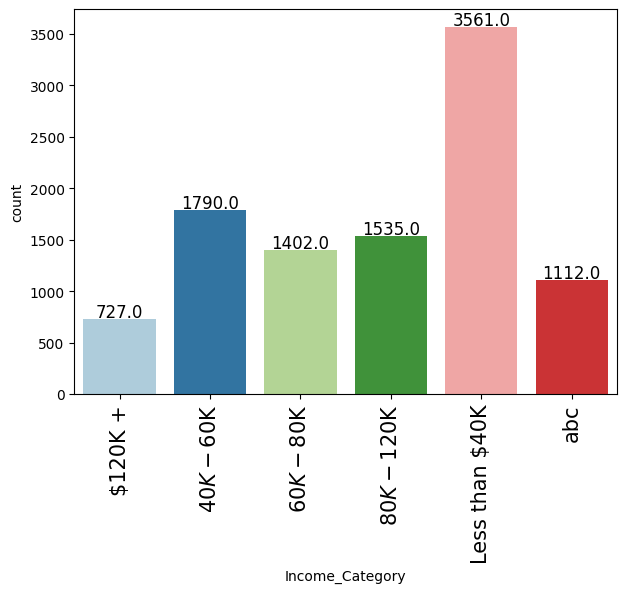

```
count              10127
unique                 6
top       Less than $40K
freq                3561
Name: Income_Category, dtype: object
```

```python
labeled_barplot(df, 'Income_Category')
df['Income_Category'].describe()
```

- Less than $40K is the most frequent income bracket by far.
- The rest are fairly evenly distributed, although there are less people with income over 120k, which is to be expected.
- It's hard to ascertain what abc is supposed to mean, likely a data error. we will have to prune or reorder this.
- We will come back to abc in the Pre-Processing stage.

```
Attrition_Flag   Attrited Customer  Existing Customer    All
Income_Category
All                           1627               8500  10127
Less than $40K                 612               2949   3561
$40K - $60K                    271               1519   1790
$80K - $120K                   242               1293   1535
$60K - $80K                    189               1213   1402
abc                            187                925   1112
$120K +                        126                601    727
------------------------------------------------------------------------------------------------------------------------
```

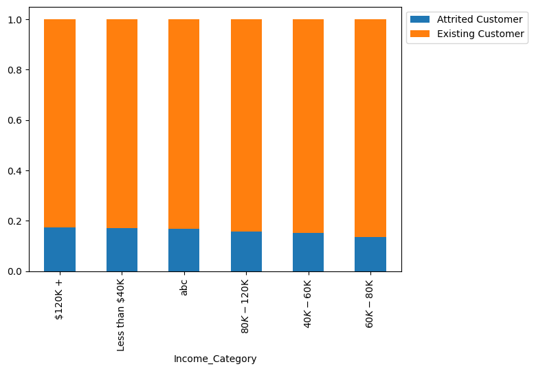

```python
stacked_barplot(df, 'Income_Category', 'Attrition_Flag')
```

- People in the over 120k bracket are most likely to close their accounts. This matches up with the trend of people with Masters and Doctorates being the most likely to close their accounts.
- Upper middle class people, or 60k-80k range are the most likely to maintain their accounts.
4. How does the change in transaction amount between Q4 and Q1 (`total_ct_change_Q4_Q1`) vary by the customer's account status (`Attrition_Flag`)?

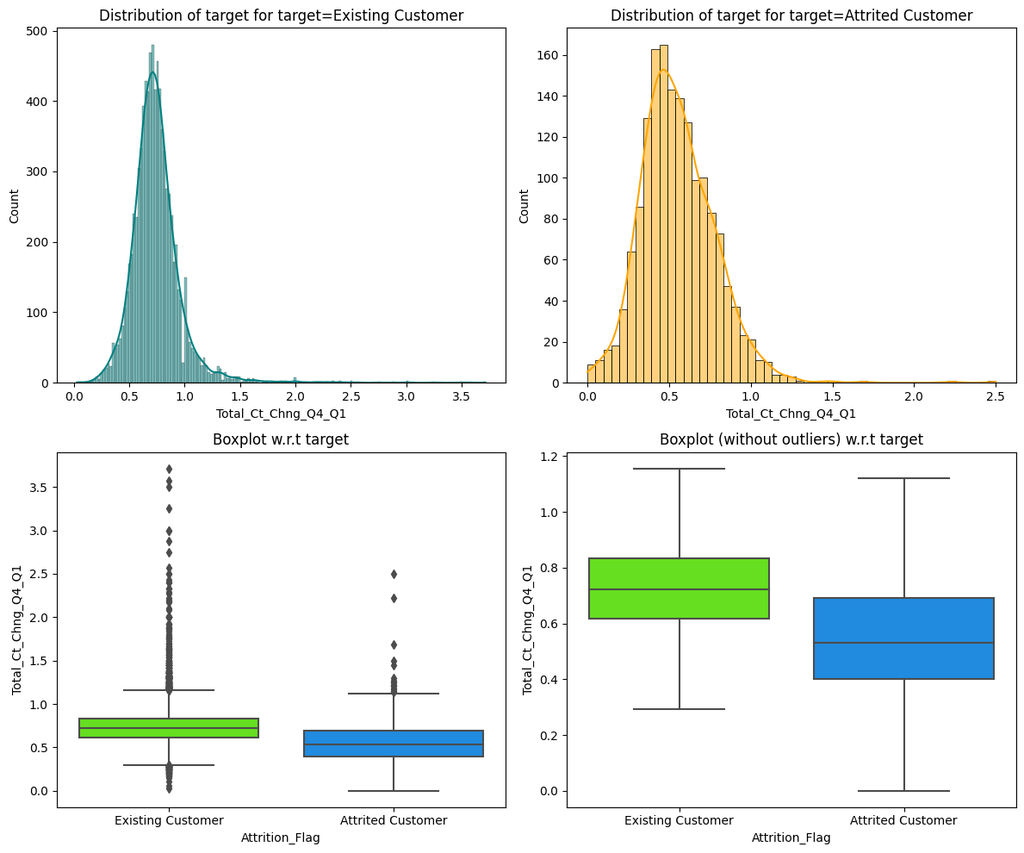

```python
distribution_plot_wrt_target(df, 'Total_Ct_Chng_Q4_Q1', 'Attrition_Flag')
```

- Seems existing customers are more likely to have a change in their accounts from quarter 1 to 4, although not by much.
5. How does the number of months a customer was inactive in the last 12 months (`Months_Inactive_12_mon`) vary by the customer's account status (`Attrition_Flag`)?

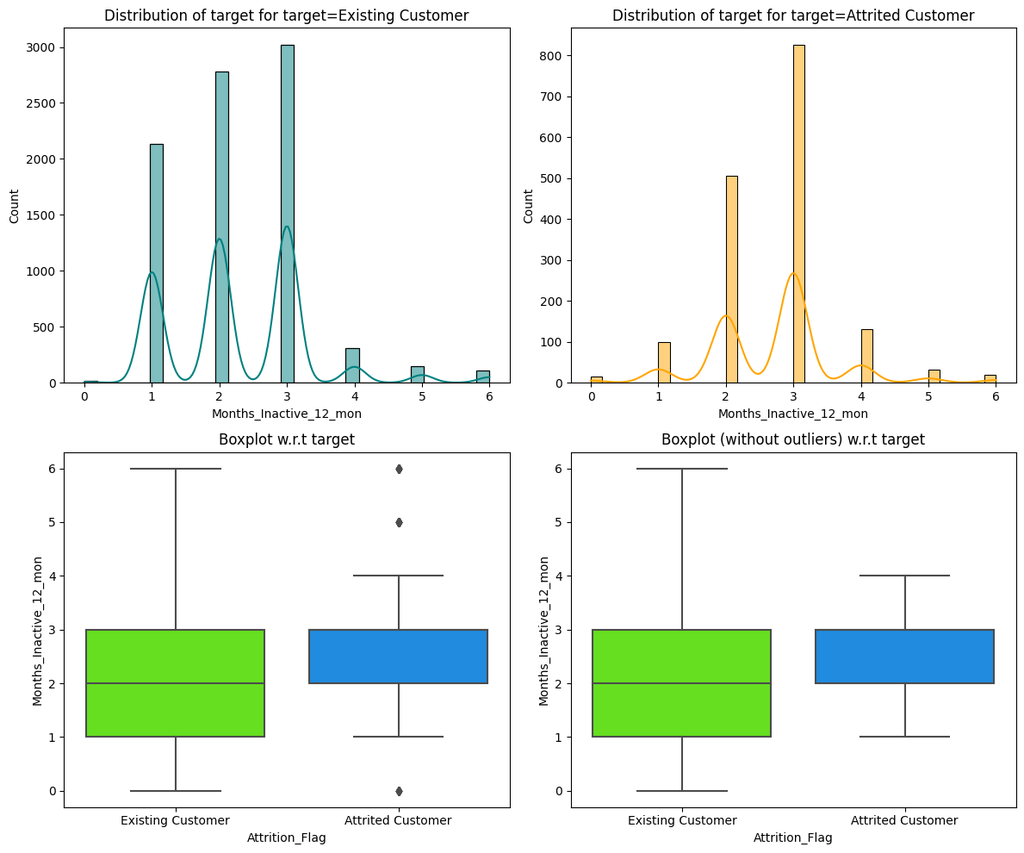

```
Months_Inactive_12_mon  Attrition_Flag
0                       Attrited Customer      15
                        Existing Customer      14
1                       Attrited Customer     100
                        Existing Customer    2133
2                       Attrited Customer     505
                        Existing Customer    2777
3                       Attrited Customer     826
                        Existing Customer    3020
4                       Attrited Customer     130
                        Existing Customer     305
5                       Attrited Customer      32
                        Existing Customer     146
6                       Attrited Customer      19
                        Existing Customer     105
dtype: int64
```

```python
distribution_plot_wrt_target(df, 'Months_Inactive_12_mon', 'Attrition_Flag')
fd = df.copy()
fd['Attrition_Flag'] = fd['Attrition_Flag'].replace({'Attrited Customer': 1, 'Existing Customer': 0})
grouped_counts = df.groupby(['Months_Inactive_12_mon', 'Attrition_Flag']).size()
print(grouped_counts)
```

- Seems existing customers and attrited customers both are primarily in the range of 1-3 months of inactivity, although the Attrited Customers have less variability in their inactivity.
- Existing customers are more likely to have 1 month of inactivty than Attrited customers.
6. What are the attributes that have a strong correlation with each other?

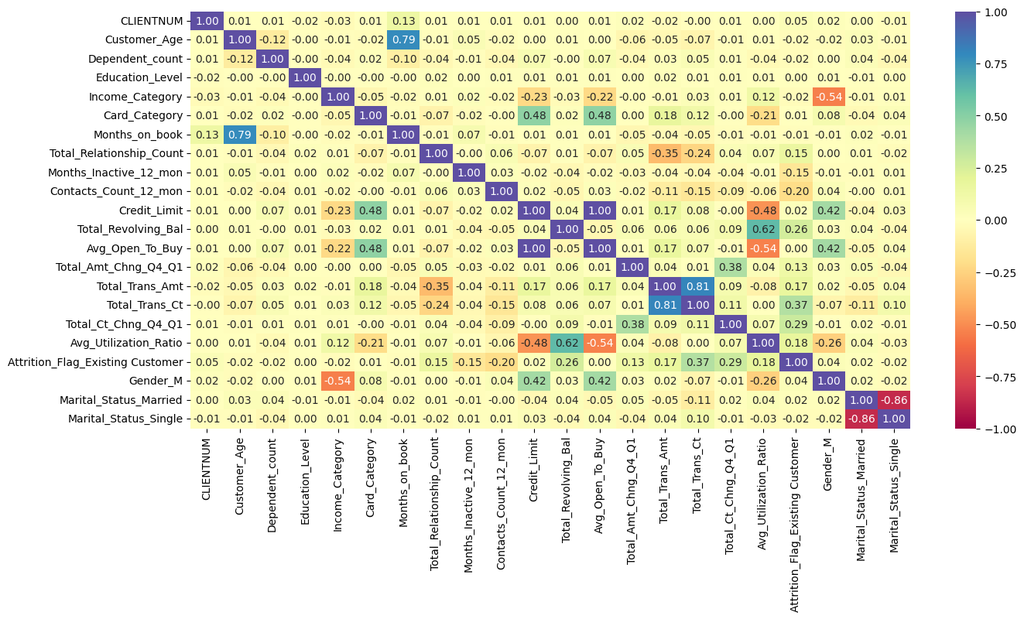

```python
#lets make a heatmap, but first we need to encode the categorical variables.
fd = df.copy()
# Fill NaN values with the most frequent value of the column
fd['Education_Level'].fillna(fd['Education_Level'].mode()[0], inplace=True)
fd['Marital_Status'].fillna(fd['Marital_Status'].mode()[0], inplace=True)
#We will use label encoding for the ordinal categorical variables:
ordinal_vars = {
    "Education_Level": ['Uneducated', 'High School', 'College', 'Graduate', 'Post-Graduate', 'Doctorate'],
    "Income_Category": ['abc', 'Less than $40K', '$40K - $60K', '$60K - $80K', '$80K - $120K', '$120K +'],
    "Card_Category": ['Blue', 'Silver', 'Gold', 'Platinum']
}

for var, ordering in ordinal_vars.items():
    label_encoder = LabelEncoder()
    label_encoder.fit(ordering)
    fd[var] = label_encoder.transform(fd[var].astype(str))
#We will use one-hot encoding for the other categorical variables:
fd = pd.get_dummies(fd, columns=['Attrition_Flag', 'Gender', 'Marital_Status'], drop_first=True)

#and finally graph the heat map
plt.figure(figsize=(15, 7))
sns.heatmap(fd.corr(), annot=True, vmin=-1, vmax=1, fmt=".2f", cmap="Spectral")
plt.show()
```

- Based on this heatmap, the following have high positive correlations:
  - Credit_Limit to Avg_Open_To_Buy at 1.00
  - Total_Trans_Amt to Total_Trans_Ct at .81
  - Months_on_book to Customer_age at .79
  - Avg_Utilization_Ratio to Total_Revolving_Bal at .62
  - Credit_Limit to Card_Category at .48
  - Avg_Open_To_Buy to Card_Category at .48
  - Total_Amt_Chng_Q4_Q1 to Total_Ct_Chng_Q4_Q1 at .38
- The following have high negative correlations:
  - Avg_Open_To_Buy to Avg_Utilization_Ratio at -.54
  - Credit_Limit to Avg_Utilization_Ratio at -.48
  - Total_Relationship_Count to Total_Trans_Amt at -.35
- The following are positive correlations with 1 hot encoding variables, so take this with a grain of salt:
  - Gender_M to Avg_Open_To_Buy at .42
  - Gender_M to Credit_Limit at .42
  - Attribution_Flag_Existing_Customer to Total_Trans_Ct at .37
  - Attribution_Flag_Existing_Customer to Total_Ct_Chng_Q4_Q1 at .29
  - Attribution_Flag_Existing_Customer to Total_Revolving_Bal at .26
  - Attribution_Flag_Existing_Customer to Avg_Utilization_Ratio at .18
- And negative correlations for hot encoding variables:
  - Gender_M to Income_Category at -.54
  - Gender_M to Avg_Utilization_Ratio at -.26
  - Attribution_Flag_Existing_Customer to Contacts_Count_12_mon at -.20
  - Attribution_Flag_Existing_Customer to Months_Inactive_12_mon at -.15
- Consider Attribution_Flag's value in what we are trying to determine, even weak correlations to it are impportant.
- Credit_Limit and Avg_Open_To_Buy are so highly correlated it almost looks like a mistake, if there wasn't slight differences in how they correlate with other variables.

## Data Pre-processing

```python
# Calculate the mode excluding 'abc'
most_frequent_value = df[df['Income_Category'] != 'abc']['Income_Category'].mode()[0]

# Replace 'abc' with the most frequent value
df['Income_Category'].replace('abc', most_frequent_value, inplace=True)
```

- Now let's check the outliers

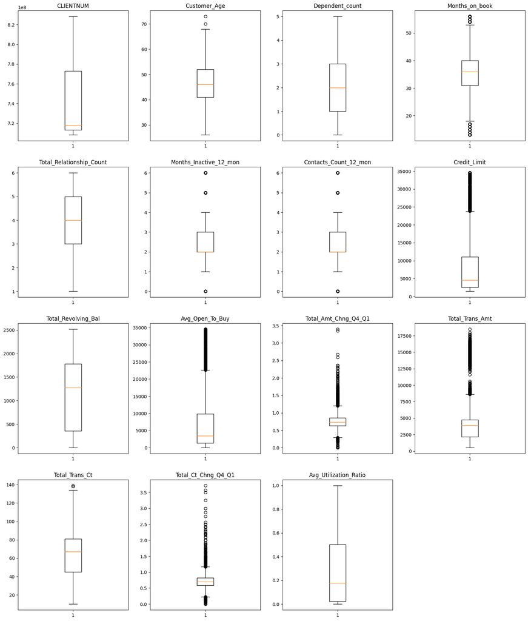

```python
# check the outliers before treating
plt.figure(figsize=(20, 30))
num_cols = df.select_dtypes(include=['int64', 'float64']).columns.tolist()

for i, variable in enumerate(num_cols):
    plt.subplot(5, 4, i + 1)
    plt.boxplot(df[variable], whis=1.5)
    plt.title(variable)

plt.show()
```

```python
# find the 25th percentile and 75th percentile.
numeric_df = df.select_dtypes(include=[np.number])
Q1 = numeric_df.quantile(0.25)
Q3 = numeric_df.quantile(0.75)

# Inter Quantile Range (75th percentile - 25th percentile)
IQR = Q3 - Q1

# find lower and upper bounds for all values. All values outside these bounds are outliers
lower=Q1-1.5*IQR
upper=Q3+1.5*IQR

# Extract the numeric columns from df
numeric_data = df[num_cols]

# Initialize an empty DataFrame to hold the outlier flags
outliers = pd.DataFrame(columns=numeric_data.columns, index=numeric_data.index)

# Iterate over columns and mark outliers
for col in numeric_data.columns:
    outliers[col] = (numeric_data[col] < lower[col]) | (numeric_data[col] > upper[col])

# Calculate percentage of outliers per column
percentage_outliers_per_column = outliers.sum() / len(df) * 100
print(percentage_outliers_per_column)
```

```
CLIENTNUM                   0.000000
Customer_Age                0.019749
Dependent_count             0.000000
Months_on_book              3.811593
Total_Relationship_Count    0.000000
Months_Inactive_12_mon      3.268490
Contacts_Count_12_mon       6.211119
Credit_Limit                9.716599
Total_Revolving_Bal         0.000000
Avg_Open_To_Buy             9.509233
Total_Amt_Chng_Q4_Q1        3.910339
Total_Trans_Amt             8.847635
Total_Trans_Ct              0.019749
Total_Ct_Chng_Q4_Q1         3.890590
Avg_Utilization_Ratio       0.000000
dtype: float64
```

- The outliers that are present aren't very impactful nor do they seem like invalid business data, so we shall leave them be.

## Missing value imputation

```python
# Fill NaN values with the most frequent value of the column
df['Education_Level'].fillna(df['Education_Level'].mode()[0], inplace=True)
df['Marital_Status'].fillna(df['Marital_Status'].mode()[0], inplace=True)
```

## Model Building

### Model evaluation criterion

**Which metric to optimize?**

**Let's define a function to output different metrics (including recall) on the train and test set and a function to show confusion matrix so that we do not have to use the same code repetitively while evaluating models.**

```python
# defining a function to compute different metrics to check performance of a classification model built using sklearn
def model_performance_classification_sklearn(model, predictors, target):
    """
    Function to compute different metrics to check classification model performance

    model: classifier
    predictors: independent variables
    target: dependent variable
    """

    # predicting using the independent variables
    pred = model.predict(predictors)

    acc = accuracy_score(target, pred)  # to compute Accuracy
    recall = recall_score(target, pred)  # to compute Recall
    precision = precision_score(target, pred)  # to compute Precision
    f1 = f1_score(target, pred)  # to compute F1-score

    # creating a dataframe of metrics
    df_perf = pd.DataFrame(
        {
            "Accuracy": acc,
            "Recall": recall,
            "Precision": precision,
            "F1": f1

        },
        index=[0],
    )

    return df_perf
```

### Model Building with original data

```python
#We will use label encoding for the ordinal categorical variables:
ordinal_vars = {
    "Education_Level": ['Uneducated', 'High School', 'College', 'Graduate', 'Post-Graduate', 'Doctorate'],
    "Income_Category": ['Less than $40K', '$40K - $60K', '$60K - $80K', '$80K - $120K', '$120K +'],
    "Card_Category": ['Blue', 'Silver', 'Gold', 'Platinum']
}

for var, ordering in ordinal_vars.items():
    label_encoder = LabelEncoder()
    label_encoder.fit(ordering)
    df[var] = label_encoder.transform(df[var].astype(str))

#We will use one-hot encoding for the other categorical variables:
df = pd.get_dummies(df, columns=['Attrition_Flag', 'Gender', 'Marital_Status'], drop_first=True)

# Separating X and y
X = df.drop(["Attrition_Flag_Existing Customer"], axis=1)
y = df["Attrition_Flag_Existing Customer"]

# Split data into training and validation sets
X_train, X_val, y_train, y_val = train_test_split(X, y, test_size=0.2, random_state=37)
```

```python
#NOTE: given that our y value is existing customers and we need to recall the failures, we need to do the inverse of recall,
# which is specificity.

#Like this
def specificity(y_true, y_pred):
    tn, fp, fn, tp = confusion_matrix(y_true, y_pred).ravel()
    return tn / (tn + fp)
```

Sample code for model building with original data

```python
models = []  # Empty list to store all the models

# Appending models into the list
models.append(("Bagging", BaggingClassifier(random_state=1)))
models.append(("Random forest", RandomForestClassifier(random_state=1)))
models.append(("AdaBoost", AdaBoostClassifier(random_state=1)))
models.append(("Gradient Boosting", GradientBoostingClassifier(random_state=1)))
models.append(("XGBoost", XGBClassifier(random_state=1)))

print("\n" "Training Performance:" "\n")
for name, model in models:
    model.fit(X_train, y_train)
    scores = specificity(y_train, model.predict(X_train))
    print("{}: {}".format(name, scores))

print("\n" "Validation Performance:" "\n")

for name, model in models:
    model.fit(X_train, y_train)
    scores_val = specificity(y_val, model.predict(X_val))
    print("{}: {}".format(name, scores_val))
```

```
Training Performance:

Bagging: 0.9992418498862775
Random forest: 1.0
AdaBoost: 0.865049279757392
Gradient Boosting: 0.8870356330553449
XGBoost: 1.0

Validation Performance:

Bagging: 0.8409090909090909
Random forest: 0.814935064935065
AdaBoost: 0.8246753246753247
Gradient Boosting: 0.814935064935065
XGBoost: 0.8668831168831169
```

- Accurate, but performance could be better on testing data. Let's see if the Oversampled and Undersampled models perform better.

### Model Building with Oversampled data

```python
# Synthetic Minority Over Sampling Technique
sm = SMOTE(sampling_strategy=1, k_neighbors=5, random_state=1)
X_train_over, y_train_over = sm.fit_resample(X_train, y_train)

overmodels = []  # Empty list to store all the oversampled models

# Appending overmodels into the list
overmodels.append(("Bagging", BaggingClassifier(random_state=1)))
overmodels.append(("Random forest", RandomForestClassifier(random_state=1)))
overmodels.append(("AdaBoost", AdaBoostClassifier(random_state=1)))
overmodels.append(("Gradient Boosting", GradientBoostingClassifier(random_state=1)))
overmodels.append(("XGBoost", XGBClassifier(random_state=1)))

print("\n" "Training Performance:" "\n")
for name, model in overmodels:
    model.fit(X_train_over, y_train_over)
    scores = specificity(y_train_over, model.predict(X_train_over))
    print("{}: {}".format(name, scores))

print("\n" "Validation Performance:" "\n")

for name, model in overmodels:
    model.fit(X_train_over, y_train_over)
    scores_val = specificity(y_val, model.predict(X_val))
    print("{}: {}".format(name, scores_val))
```

```
Training Performance:

Bagging: 0.9995576526098496
Random forest: 1.0
AdaBoost: 0.9572397522854615
Gradient Boosting: 0.9691831318195223
XGBoost: 1.0

Validation Performance:

Bagging: 0.8993506493506493
Random forest: 0.8928571428571429
AdaBoost: 0.8831168831168831
Gradient Boosting: 0.8993506493506493
XGBoost: 0.9058441558441559
```

- Performance is better on training and testing, definitely and improvement. Now let's see undersampling.

### Model Building with Undersampled data

```python
# Random undersampler for under sampling the data
rus = RandomUnderSampler(random_state=1, sampling_strategy=1)
X_train_un, y_train_un = rus.fit_resample(X_train, y_train)

undermodels = []  # Empty list to store all the undersampled models

# Appending undermodels into the list
undermodels.append(("Bagging", BaggingClassifier(random_state=1)))
undermodels.append(("Random forest", RandomForestClassifier(random_state=1)))
undermodels.append(("AdaBoost", AdaBoostClassifier(random_state=1)))
undermodels.append(("Gradient Boosting", GradientBoostingClassifier(random_state=1)))
undermodels.append(("XGBoost", XGBClassifier(random_state=1)))

print("\n" "Training Performance:" "\n")
for name, model in undermodels:
    model.fit(X_train_un, y_train_un)
    scores = specificity(y_train_un, model.predict(X_train_un))
    print("{}: {}".format(name, scores))

print("\n" "Validation Performance:" "\n")

for name, model in undermodels:
    model.fit(X_train_un, y_train_un)
    scores_val = specificity(y_val, model.predict(X_val))
    print("{}: {}".format(name, scores_val))
```

```
Training Performance:

Bagging: 0.9992418498862775
Random forest: 1.0
AdaBoost: 0.9658832448824868
Gradient Boosting: 0.9833206974981046
XGBoost: 1.0

Validation Performance:

Bagging: 0.9253246753246753
Random forest: 0.948051948051948
AdaBoost: 0.9253246753246753
Gradient Boosting: 0.948051948051948
XGBoost: 0.948051948051948
```

- These models are performing the best out of the 3 so we will use these. Although they are definitely overfit considering they perform better on training data than testing data, let's see if tuning will help.

### HyperparameterTuning

#### Sample Parameter Grids

**Hyperparameter tuning can take a long time to run, so to avoid that time complexity - you can use the following grids, wherever required.**

- For Gradient Boosting:

```
param_grid = {
    "init": [AdaBoostClassifier(random_state=1),DecisionTreeClassifier(random_state=1)],
    "n_estimators": np.arange(75,150,25),
    "learning_rate": [0.1, 0.01, 0.2, 0.05, 1],
    "subsample":[0.5,0.7,1],
    "max_features":[0.5,0.7,1],
}
```

- For Adaboost:

```
param_grid = {
     "n_estimators": np.arange(10, 110, 10),
     "learning_rate": [0.1, 0.01, 0.2, 0.05, 1],
     "base_estimator": [
         DecisionTreeClassifier(max_depth=1, random_state=1),
         DecisionTreeClassifier(max_depth=2, random_state=1),
         DecisionTreeClassifier(max_depth=3, random_state=1),
    ]
}
```

- For Bagging Classifier:

```
param_grid = {
    'max_samples': [0.8,0.9,1],
    'max_features': [0.7,0.8,0.9],
    'n_estimators' : [30,50,70],
}
```

- For Random Forest:

```
param_grid = {
    "n_estimators": [200,250,300],
    "min_samples_leaf": np.arange(1, 4),
    "max_features": [np.arange(0.3, 0.6, 0.1),'sqrt'],
    "max_samples": np.arange(0.4, 0.7, 0.1)
}
```

- For Decision Trees:

```
param_grid = {
    'max_depth': np.arange(2,6),
    'min_samples_leaf': [1, 4, 7],
    'max_leaf_nodes' : [10, 15],
    'min_impurity_decrease': [0.0001,0.001]
}
```

- For XGBoost:

```
param_grid={
   'n_estimators':np.arange(50,300,50),
   'scale_pos_weight':[0,1,2,5,10],
   'learning_rate':[0.01,0.1,0.2,0.05],
   'gamma':[0,1,3,5],
   'subsample':[0.7,0.8,0.9,1]
}
```

- The three models we will be using are:

#### Undersampled Random Forest

  - Although overfit with a perfect recall score on the training data, a very high performance on validation data at .948. Random forests are less likely to overfit in general due to the ensemble nature, and we really need to cut down on overfitting. Additionally, Random Forest inherently provides feature importance, aiding in model interpretability. Random Forest is arguably more overfit for all 3 versions than the other methods, so if it still shows signs of ovefitting after tuning, we will go with something else.

#### Undersampled XGBoost

  - Just like random forest, definitely overfit the training data, but also performaed well on the validation set. Also, like it's cousin Gradient Boosting, XGBoost tends to benefit from hyperparameter tuning as it has a lot of options for hyperparameter tuning.

#### Undersampled Gradient Boosting

  - Highest performance of all 3 Gradient Boosting models. On par with Random Forest and XGBoost. Also, Gradient Boosting tends to be resistant to overfitting. Also, Gradient Boosting tends to benefit from hyperparameter tuning.

#### Determing the best parameters for Undersampled Gradient Boosting

```python
# defining model
GradientModel = undermodels[3][1]

# Parameter grid to pass in RandomSearchCV
param_grid = {
    "init": [AdaBoostClassifier(random_state=1),DecisionTreeClassifier(random_state=1)],
    "n_estimators": np.arange(75,150,25),
    "learning_rate": [0.1, 0.01, 0.2, 0.05, 1],
    "subsample":[0.5,0.7,1],
    "max_features":[0.5,0.7,1],
}

#make scorer based on recall
scorer = make_scorer(specificity)

#Calling RandomizedSearchCV
randomized_cv = RandomizedSearchCV(estimator=GradientModel, param_distributions=param_grid, n_iter=50, n_jobs = -1, scoring=scorer, cv=5, random_state=1)

#Fitting parameters in RandomizedSearchCV
randomized_cv.fit(X_train_un,y_train_un)

print("Best parameters are {} with CV score={}:" .format(randomized_cv.best_params_,randomized_cv.best_score_))
```

```
Best parameters are {'subsample': 0.7, 'n_estimators': 125, 'max_features': 0.7, 'learning_rate': 0.2, 'init': AdaBoostClassifier(random_state=1)} with CV score=0.962844221684526:
```

#### Determing the best parameters Undersampled Random Forest

```python
# defining model
RFModel = undermodels[1][1]

# Parameter grid to pass in RandomSearchCV
param_grid = {
    "n_estimators": [200,250,300],
    "min_samples_leaf": np.arange(1, 4),
    "max_features": list(np.arange(0.3, 0.6, 0.1)) + ['sqrt'],
    "max_samples": np.arange(0.4, 0.7, 0.1)
}

#make scorer based on recall
scorer = make_scorer(specificity)

#Calling RandomizedSearchCV
randomized_cv = RandomizedSearchCV(estimator=RFModel, param_distributions=param_grid, n_iter=50, n_jobs = -1, scoring=scorer, cv=5, random_state=1)

#Fitting parameters in RandomizedSearchCV
randomized_cv.fit(X_train_un,y_train_un)

print("Best parameters are {} with CV score={}:" .format(randomized_cv.best_params_,randomized_cv.best_score_))
```

```
Best parameters are {'n_estimators': 300, 'min_samples_leaf': 1, 'max_samples': 0.5, 'max_features': 0.5} with CV score=0.961326189653186:
```

#### Determing the best parameters for Undersampled XGBoost

```python
# defining model
XGBModel = undermodels[4][1]

# Parameter grid to pass in RandomSearchCV
param_grid={
   'n_estimators':np.arange(50,300,50),
   'scale_pos_weight':[0,1,2,5,10],
   'learning_rate':[0.01,0.1,0.2,0.05],
   'gamma':[0,1,3,5],
   'subsample':[0.7,0.8,0.9,1]
}

#make scorer based on recall
scorer = make_scorer(specificity)

#Calling RandomizedSearchCV
randomized_cv = RandomizedSearchCV(estimator=XGBModel, param_distributions=param_grid, n_iter=50, n_jobs = -1, scoring=scorer, cv=5, random_state=1)

#Fitting parameters in RandomizedSearchCV
randomized_cv.fit(X_train_un,y_train_un)

print("Best parameters are {} with CV score={}:" .format(randomized_cv.best_params_,randomized_cv.best_score_))
```

```
Best parameters are {'subsample': 0.9, 'scale_pos_weight': 0, 'n_estimators': 250, 'learning_rate': 0.01, 'gamma': 5} with CV score=1.0:
```

#### Training the best models with generated hyperparameters

```python
# Undersampled Random Forest
best_rf = RandomForestClassifier(
    n_estimators=300, min_samples_leaf=1, max_samples=0.5, max_features=0.5, random_state=1
)
best_rf.fit(X_train_un, y_train_un)

# Undersampled XGBoost
best_xgb = XGBClassifier(
    subsample=0.9, scale_pos_weight=0, n_estimators=250, learning_rate=0.01, gamma=5, random_state=1
)
best_xgb.fit(X_train_un, y_train_un)

# Undersampled Gradient Boost
best_gbc = GradientBoostingClassifier(
    subsample=0.7, n_estimators=125, max_features=0.7, learning_rate=0.2, init=AdaBoostClassifier(random_state=1), random_state=1
)
best_gbc.fit(X_train_un, y_train_un)
```

```
GradientBoostingClassifier(init=AdaBoostClassifier(random_state=1),
                           learning_rate=0.2, max_features=0.7,
                           n_estimators=125, random_state=1, subsample=0.7)
```